# Obdelava 45. vaje

## TULJAVA V MAGNETNEM POLJU

Gregor Žunič, 8.4.2020

### Uvod

Navor, ki ga proizvede tuljava s presekom S, z N ovoji, skozi katero teče tok I, v zunanjem magnetnem polju B, lahko izračunamo kot:

$$ M = NIS \times B$$

kjer je $NIS$ dipolni moment $p_m$.

Zunanje magnetno polje $B$ naredimo z parom Helmholtzovih tuljav. Vsaka ima $N_h$ ovojev, radij $R_h$ in skozi vsako teče tok $I_h$, med seboj pa sta oddaljeni $R_h$. Velikost $B$ je:

$$ B = (\frac{4}{5})^{3/2} \frac{\mu_0 N_h I_h}{R_h} $$

Iz tega sledi

$$ M = (\frac{4}{5})^{3/2} \frac{\mu_0 N N_h I_h IS}{R_h} \cdot \sin{\phi} $$

kot $\phi$, pa smo poskušali ves čas konstano držati na $\frac{\pi}{2}$.

### Naloga

Z uravnovešenjem navora na tuljavo v homogenem magnetnem polju Helmholtzove tuljave določi indukcijsko konstanto!

### Obdelava in rezultati

```python
import csv
from scipy.optimize import curve_fit
import math
import matplotlib.pyplot as plt
import numpy as np
import pandas as pd
from IPython.display import display, Image
```

|  | M | Ih | I |
| --- | --- | --- | --- |
| 0 | 1.0 | 2890 | 1421 |
| 1 | 1.2 | 2889 | 1841 |
| 2 | 1.4 | 2888 | 2147 |
| 3 | 1.6 | 2888 | 2459 |
| 4 | 1.8 | 2888 | 2774 |
| 5 | 2.0 | 2890 | 3107 |
| 6 | 1.0 | 1881 | 2396 |
| 7 | 1.0 | 3104 | 1468 |
| 8 | 1.0 | 2700 | 1700 |
| 9 | 1.0 | 2108 | 2103 |

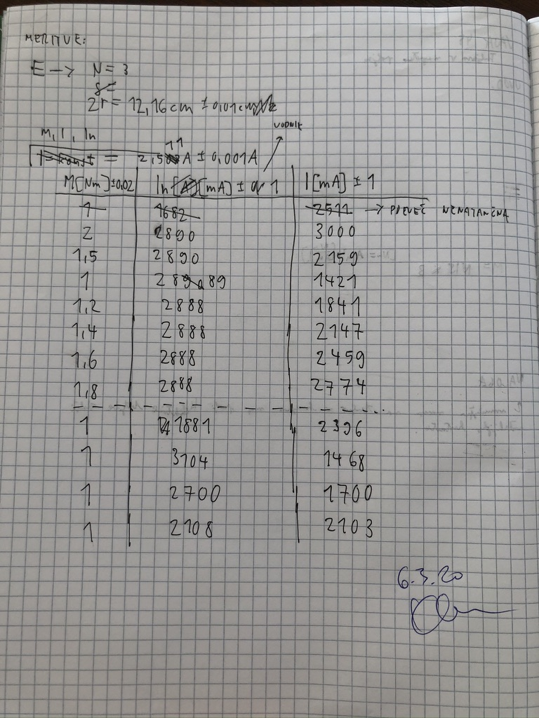

```python
data = pd.read_csv('rezultati.csv')

display(data)

M = data['M'] # v mN

Image(filename='podatki.jpeg',width=500)
```

Na y os postavimo izmerjene navore ($M$) v pravih enotah ($nM$), na x os pa navedemo meritve povezane z enačbo v enotah $A^2m$, $$(\frac{4}{5})^{3/2} \frac{1}{R_h}\cdot N N_h I_h S \cdot I \: [A^2\cdot \frac{m^2}{m} = A^2 m]$$

kar z dimenzijsko analizo lahko potrdimo da zares dobimo navor, če napišemo $\mu_0$, kot v $[\frac{N}{A^2}]$.

```python
def fit_func(x, a, b):
    return x*a+b

N = 3
Nh = 154
Rh = 0.2
r = 0.1216/2

S = math.pi*r**2

x = [(4/5)**(3/2) *N*Nh*S/Rh *row['I']*row['Ih']*10**-6 for index,row in data.iterrows()]
# pretvorba v Nm (Newton metre)
y = [y * 10 **-4 for y in M]
print(x,y)
```

```
[78.83079607203665, 102.09519946666092, 119.02363922120293, 136.32004138096787, 153.7827550999613, 172.36262026447423, 86.51264713868255, 87.46851629880983, 88.1082706439123, 85.09692574946037] [0.0001, 0.00012, 0.00014, 0.00016, 0.00018, 0.0002, 0.0001, 0.0001, 0.0001, 0.0001]
```

```python
params = curve_fit(
    fit_func, x[1:-1], y[1:-1])
a = params[0][0]
b = params[0][1]

# CALCULATE ERRORS FROM MATRIX
errs = np.sqrt(np.diag(params[1]))
print('a =', a,'Vs/Am','+-',errs[0],'Vs/Am', '\nb =', b,'+-',errs[1])
```

```
a = 1.185294859650485e-06 Vs/Am +- 1.7092685221217052e-08 Vs/Am
b = -2.6127703860560957e-06 +- 2.0884355974235144e-06
```

```python
x_fit = np.linspace(0, max(x)+5, 100)

y_fit = fit_func(x_fit, a, b)

plt.plot(x, y, 'o')
plt.plot(x_fit, y_fit, label=r'$k = \mu_0$')

plt.title(r'$M \sim I,I_h$')
plt.ylabel(r'$M \; [Nm]$')
plt.xlabel(r'$(\frac{4}{5})^{3/2} \frac{1}{R_h}\cdot N N_h I_h S \cdot I \: [A^2m]$')

plt.legend()
plt.show()
```

[figure not shown]

Naklon grafa ($= \mu_0$), ki je očitno linearna odvisnost med točkami:

$$ \mu_0 = (1.1852 \pm 0.017) \cdot 10^{-6} \frac{Vs}{Am} (\frac{N}{A^2}) $$

V literaturi predpisana vrednost je: $$ \mu_0 = 4\pi \cdot 10^{-7} \frac{Vs}{Am} $$

```python
print(abs(a - 4*math.pi *10**-7) / a)
```

```
0.060189412958788414
```

Moj rezultat se od literature razlikuje za 6%, kar je precej blizu dejanski vrednosti $\mu_0$.

### Vprašanja

1. Kako določimo smer magnetnega polja znotraj tuljave, če poznamo smer ele- ktričnega toka?

   S pravilom desne roke (po načelu vijaka).
2. Kakšno smer ima vektor navora, ki deluje na tuljavo v magnetnem polju?

   Smer vektorskega produkta med $B \times I$ ali po pravilu desne roke.
3. Kako je navor odvisen od kota med smerjo magnetnega polja in osjo tuljave?

   Sorazmeren je s sinusom kota, če je kot med magnetnim poljem in ploskovnim vektorjem tuljave 0, je tudi navor 0, če je kot $\pi/2$, je navor maksimalen.